# disorderedChannel

```julia
using Revise, BenchmarkTools, PyPlot, MATLAB
using Statistics, LinearAlgebra
using EvolutionaryDynamics
import mEvoFunc, mUtils
```

```julia
# data constants
const NEPOCHS, LOGFASMPL = 1, 1/5

# evolution and population constants
const NGEN, NPOP = Int32(500), Int32(10^4)
const REPFACTOR, PNTMUTFACTOR, NMUTMAX = 10.0, 0.07, Int32(15)
const SCALINGFACTOR = 1

# metagenotypic constants
const SYSTEMSIZE, PVIABILITY, KOUT = Int32(6), 1.0, 100.0
const GMIN, GMAX = -1.5, 1.5

# environmental constants
const SELSTRENGTH, NIO = 0.8, Int32(4);
const HIGHFLOW, LOWFLOW = 1.0, 10.0^-4;
```

```
WARNING: redefining constant SELSTRENGTH
```

```julia
# genotypic and metagenotypic types
aDisChnMetaGty = [ mEvoFunc.tDisChnMetaGty( SYSTEMSIZE, PVIABILITY, KOUT ) ]

# uniformly distributed initial genotypic variables
aDisChnGty = [ tCntGty( [aDisChnMetaGty[1]], GMIN .+ rand( aDisChnMetaGty[1].dG ) .* (GMAX - GMIN), [GMIN,GMAX] ) for i in 1:REPFACTOR*NPOP ];

# normally distributed initial genotypic variables
# aDisChnGty = [ tCntGty( [aDisChnMetaGty[1]], randn( aDisChnMetaGty[1].dG ), [GMIN,GMAX] ) for i in 1:REPFACTOR*NPOP ];

# niched array of genotypes
aDisChnGtyElite = deepcopy(aDisChnGty[1:NPOP]);
aDisChnGtyNiche = deepcopy(aDisChnGty[1:NPOP]);

# metagenotypes and genotypes from file
# aIsingMetaGty, aIsingGty, Npop = mEvoFunc.read_aIsingSigTransGty(isingDTMCprm,"test_#1")
```

```julia
# environmental and evotypic types: RANDOM IO
aIO = [ [ rand((LOWFLOW,HIGHFLOW),SYSTEMSIZE), rand((LOWFLOW,HIGHFLOW),SYSTEMSIZE) ] for i in 1:NIO ]
for io in aIO io[2] = io[2] ./ sum(io[2]) end
```

```julia
# adding random input--outputs to computational environment
newIO = [ rand((LOWFLOW,HIGHFLOW),SYSTEMSIZE), rand((LOWFLOW,HIGHFLOW),SYSTEMSIZE) ]
newIO[2] = newIO[2] ./ sum(newIO[2])
push!(disChnEnv.IOidl, newIO);
```

```julia
# environmental and evotypic types: DESIGNED BOOLEAN AND-GATE IO
aIO = [
    [ [HIGHFLOW, HIGHFLOW, HIGHFLOW, HIGHFLOW, HIGHFLOW, HIGHFLOW], [HIGHFLOW, HIGHFLOW, LOWFLOW, LOWFLOW, LOWFLOW, LOWFLOW] ],
    [ [HIGHFLOW, HIGHFLOW, HIGHFLOW, HIGHFLOW, LOWFLOW, LOWFLOW], [LOWFLOW, LOWFLOW, LOWFLOW, LOWFLOW, HIGHFLOW, HIGHFLOW] ],
    [ [LOWFLOW, LOWFLOW, HIGHFLOW, HIGHFLOW, HIGHFLOW, HIGHFLOW], [LOWFLOW, LOWFLOW, LOWFLOW, LOWFLOW, HIGHFLOW, HIGHFLOW] ],
    [ [LOWFLOW, LOWFLOW, HIGHFLOW, HIGHFLOW, LOWFLOW, LOWFLOW], [LOWFLOW, LOWFLOW, LOWFLOW, LOWFLOW, HIGHFLOW, HIGHFLOW] ]
]
for io in aIO io[2] = io[2] ./ sum(io[2]) end
```

```julia
disChnEnv = tCompEnv(aIO, SELSTRENGTH)
disChnEty = tPntMutEty(REPFACTOR,PNTMUTFACTOR,[ aDisChnMetaGty[1].dG ],NMUTMAX);

# print IOideal
for io in disChnEnv.IOidl
    println( replace(e -> e == 1.0 ? 1 : 0, io[1])," → ", replace( x -> x >= 1/SYSTEMSIZE ? 1 : 0, io[2]) )
end
```

```
[1.0, 1.0, 1.0, 1.0, 1.0, 1.0] → [1.0, 1.0, 0.0, 0.0, 0.0, 0.0]
[1.0, 1.0, 1.0, 1.0, 0.0, 0.0] → [0.0, 0.0, 0.0, 0.0, 1.0, 1.0]
[0.0, 0.0, 1.0, 1.0, 1.0, 1.0] → [0.0, 0.0, 0.0, 0.0, 1.0, 1.0]
[0.0, 0.0, 1.0, 1.0, 0.0, 0.0] → [0.0, 0.0, 0.0, 0.0, 1.0, 1.0]
```

```julia
@time disChnPop = mEvoFunc.initEvoPop( NPOP,disChnEty,disChnEnv,aDisChnMetaGty,aDisChnGty );
@time disChnPopElite = mEvoFunc.initEvoPop( NPOP,disChnEty,disChnEnv,aDisChnMetaGty,aDisChnGtyElite );
@time disChnPopNiche = mEvoFunc.initEvoPop( NPOP,disChnEty,disChnEnv,aDisChnMetaGty,aDisChnGtyNiche );
```

```
  1.316920 seconds (3.37 M allocations: 572.698 MiB)
  1.377208 seconds (3.38 M allocations: 575.104 MiB)
  1.364347 seconds (3.39 M allocations: 575.735 MiB)
```

```julia
aDisChnData = tEvoData[];
aDisChnDataElite = tEvoData[];
aDisChnDataNiche = tEvoData[];
```

```julia
for i in 1:NEPOCHS
    push!( aDisChnData, tEvoData(NGEN, LOGFASMPL) )
    push!( aDisChnDataElite, tEvoData(NGEN, LOGFASMPL) )
    push!( aDisChnDataNiche, tEvoData(NGEN, LOGFASMPL) )
    mEvoFunc.evolutionGKP!(disChnPop,aDisChnData[end],elite=false)
    mEvoFunc.evolutionGKP!(disChnPopElite,aDisChnDataElite[end],elite=true)
    mEvoFunc.evolutionOneNiches!(disChnPopNiche,aDisChnDataNiche[end])
end
```

```
Evolutionary achievement at generation 1: ⟨f⟩ = 0.4923716449860507
```

```
Evolutionary Dynamics Status: 100%|█████████████████████| Time: 0:15:44
```

```
Evolutionary achievement at generation 1: ⟨f⟩ = 0.5950528442999251
```

```
Evolutionary Dynamics Status: 100%|█████████████████████| Time: 0:16:35
```

```
Evolutionary achievement at generation 1: ⟨f⟩ = 0.5602985484383963
```

```
Evolutionary Dynamics Status: 100%|█████████████████████| Time: 0:15:03
```

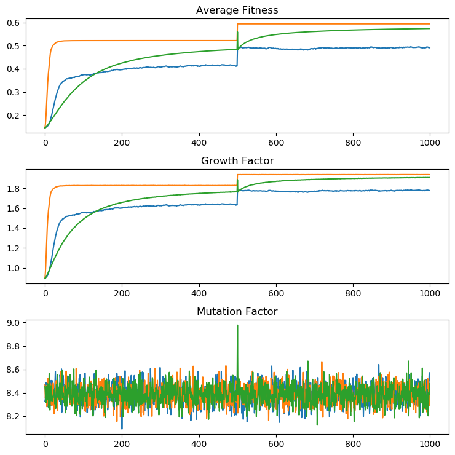

```julia
subplots(3,1,figsize=(7.5,7.5))
subplot(311); title("Average Fitness");
    plot( vcat([dataBtc.aveFitness for dataBtc in aDisChnData]...) );
    plot( vcat([dataBtc.aveFitness for dataBtc in aDisChnDataElite]...) );
    plot( vcat([dataBtc.aveFitness for dataBtc in aDisChnDataNiche]...) );
subplot(312); title("Growth Factor");
    plot( vcat([dataBtc.growthFactor for dataBtc in aDisChnData]...) );
    plot( vcat([dataBtc.growthFactor for dataBtc in aDisChnDataElite]...) );
    plot( vcat([dataBtc.growthFactor for dataBtc in aDisChnDataNiche]...) );
subplot(313); title("Mutation Factor");
    plot( vcat([dataBtc.mutationFactor for dataBtc in aDisChnData]...) );
    plot( vcat([dataBtc.mutationFactor for dataBtc in aDisChnDataElite]...) );
    plot( vcat([dataBtc.mutationFactor for dataBtc in aDisChnDataNiche]...) );
tight_layout();
```

```julia
Nsmpls = 100

ldf = REPFACTOR*mean(aDisChnData[end].aveFitness[end-Nsmpls:end]) - mean(aDisChnData[end].growthFactor[end-Nsmpls:end])
```

```
3.1475013183032217
```

## System Properties

```julia
aDisChnMetaGty[1].dG, 4aDisChnMetaGty[1].L2mL
```

```julia
[ mEvoFunc.response(aDisChnGty[1], io[1]) for io in disChnEnv.IOidl ];
```

## Genotype and Response Analysis

Observations:

- I/O shape the system. As more and more I/O are imposed, more and more genotypic variables become constrained, and their correlations become more and more polarized. How to quantify the Capacity: i.e. how many I/O can be encoded.
- For the response variables, it is hard to distinguish correlations induced by the selection from the intrinsic correlations, as the latter are not trivial in the first place ... not to forget phylogeny.
- Higher selection strength seems to polarize correlations, both genotypic and phenotypic ones. This occured even though the fitness is very low (achieved via selection strength quenching/sudden switch). In this regime, the distribution of response variables seems to be power law, and the eigenvalue distribution sparser.
- Elite selection speeds up the evolution towards fitter individuals but reduces the "genetic variance" of the population. Indeed, the correlations of both genotypic and response variables become highly polarized, as for high selection strength. It seems like an analogy with capacity can be of help: think of differing genotpyes as liquid molecules in a vessel. When we squeeze the vessel some of the liquid get lost.

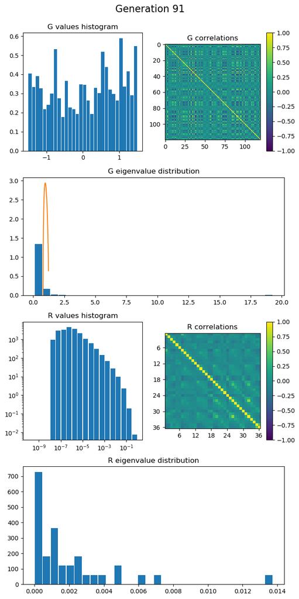

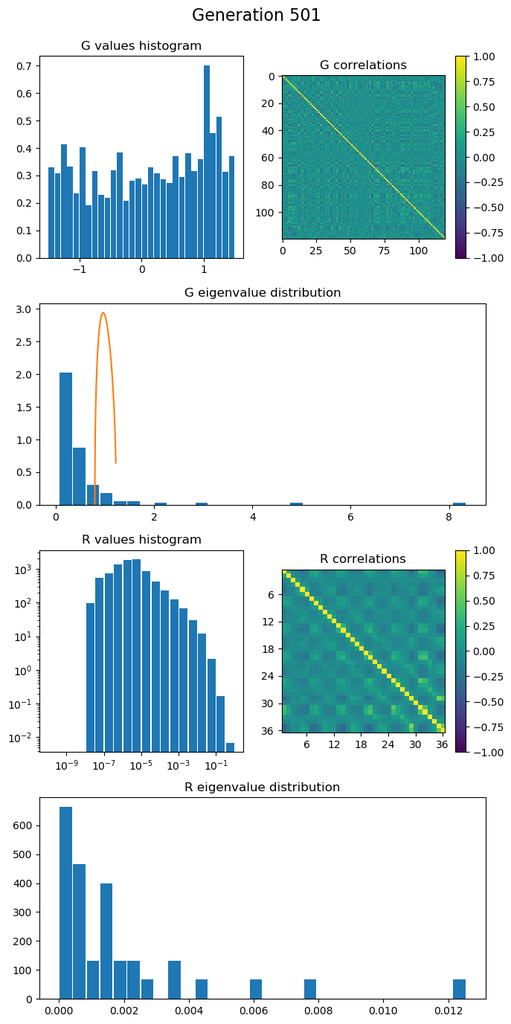

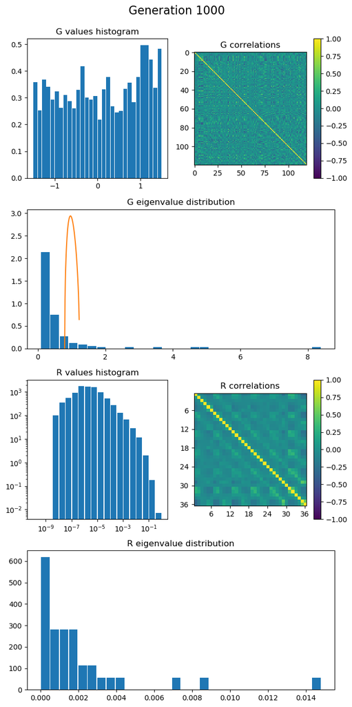

```julia
Nbatch, iPop, iGty = length(aDisChnData), 1, 1

r = aDisChnMetaGty[1].dG/NPOP

Gstat = tStat(aDisChnGty[iPop])
Rstat = tStat(aDisChnMetaGty[1].L2)

λval = [ λ for λ in mUtils.MPpdf(0,r)[2]:0.01:mUtils.MPpdf(0,r)[3] ]
MPval = [ mUtils.MPpdf(λ,r)[1] for λ in mUtils.MPpdf(0,r)[2]:0.01:mUtils.MPpdf(0,r)[3] ];

for iBatch in eachindex(aDisChnData), iPop in eachindex(aDisChnData[iBatch].aEvoPop)
    gen = aDisChnData[iBatch].aGen[iPop] + ( iBatch > 1 ? sum([ aDisChnData[jBatch].Ngen for jBatch in 1:iBatch-1]) : 0 )
    mEvoFunc.getGStat!(aDisChnData[iBatch].aEvoPop[iPop], Gstat)
    aResp = mEvoFunc.getRStat!(aDisChnData[iBatch].aEvoPop[iPop], Rstat)

    evGCor = eigvals( Symmetric(Gstat.cov) )
    evRCor = eigvals( Symmetric(Rstat.cov) )

    subplots(4,2,figsize=(7,14))
    subplot(421); title("G values histogram");  hist(vcat( [aDisChnData[iBatch].aEvoPop[iPop].aGty[i].G for i in 1:aDisChnData[iBatch].aEvoPop[iPop].pN[2]]... ), collect(aDisChnData[iBatch].aEvoPop[iPop].aGty[1].gbounds[1]:.1:aDisChnData[iBatch].aEvoPop[iPop].aGty[1].gbounds[2]), density=true,rwidth=.9);
    subplot(422); title("G correlations"); imshow(Gstat.cor,cmap="viridis",vmin=-1,vmax=1); colorbar();
    subplot(412); title("G eigenvalue distribution"); hist(evGCor,30,density=true,log=false,rwidth=.9); plot(λval,MPval)

    subplot(425); title("R values histogram"); hist( reshape(aResp,:,1), [10^i for i in -10:.5:0], log=true, density=true, rwidth=.9); xscale("log");
    subplot(426); title("R correlations"); imshow(Rstat.cor,cmap="viridis",vmin=-1,vmax=1); colorbar(); xticks(disChnPop.aMetaGty[1].L-1:disChnPop.aMetaGty[1].L:disChnPop.aMetaGty[1].L2,disChnPop.aMetaGty[1].L:disChnPop.aMetaGty[1].L:disChnPop.aMetaGty[1].L2); yticks(disChnPop.aMetaGty[1].L-1:disChnPop.aMetaGty[1].L:disChnPop.aMetaGty[1].L2,disChnPop.aMetaGty[1].L:disChnPop.aMetaGty[1].L:disChnPop.aMetaGty[1].L2);
    subplot(414); title("R eigenvalue distribution"); hist(evRCor,30,density=true,log=false,rwidth=.9);

    suptitle("Generation $gen", fontsize=16)
    tight_layout(); subplots_adjust(top=0.9333);
end

gen = sum([aDisChnData[jBatch].Ngen for jBatch in 1:Nbatch])
mEvoFunc.getGStat!(disChnPop, Gstat)
aResp = mEvoFunc.getRStat!(disChnPop, Rstat)

evGCor = eigvals( Symmetric(Gstat.cov) )
evRCor = eigvals( Symmetric(Rstat.cov) )

subplots(4,2,figsize=(7,14))
subplot(421); title("G values histogram");  hist(vcat( [disChnPop.aGty[i].G for i in 1:disChnPop.pN[2]]... ), collect(disChnPop.aGty[1].gbounds[1]:.1:disChnPop.aGty[1].gbounds[2]), density=true,rwidth=.9);
subplot(422); title("G correlations"); imshow(Gstat.cor,cmap="viridis",vmin=-1,vmax=1); colorbar();
subplot(412); title("G eigenvalue distribution"); hist(evGCor,30,density=true,log=false,rwidth=.9); plot(λval,MPval)

subplot(425); title("R values histogram"); hist( reshape(aResp,:,1), [10^i for i in -10:.5:0], log=true, density=true, rwidth=.9); xscale("log");
subplot(426); title("R correlations"); imshow(Rstat.cor,cmap="viridis",vmin=-1,vmax=1); colorbar();
xticks(disChnPop.aMetaGty[1].L-1:disChnPop.aMetaGty[1].L:disChnPop.aMetaGty[1].L2,disChnPop.aMetaGty[1].L:disChnPop.aMetaGty[1].L:disChnPop.aMetaGty[1].L2);
yticks(disChnPop.aMetaGty[1].L-1:disChnPop.aMetaGty[1].L:disChnPop.aMetaGty[1].L2,disChnPop.aMetaGty[1].L:disChnPop.aMetaGty[1].L:disChnPop.aMetaGty[1].L2);
subplot(414); title("R eigenvalue distribution"); hist(evRCor,30,density=true,log=false,rwidth=.9);

suptitle("Generation $gen", fontsize=16)
tight_layout(); subplots_adjust(top=0.9333);
```

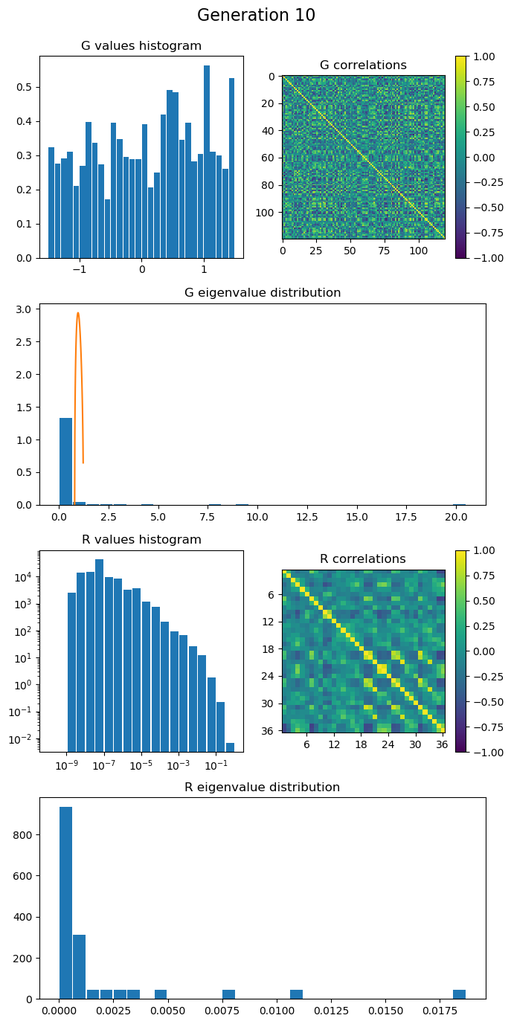

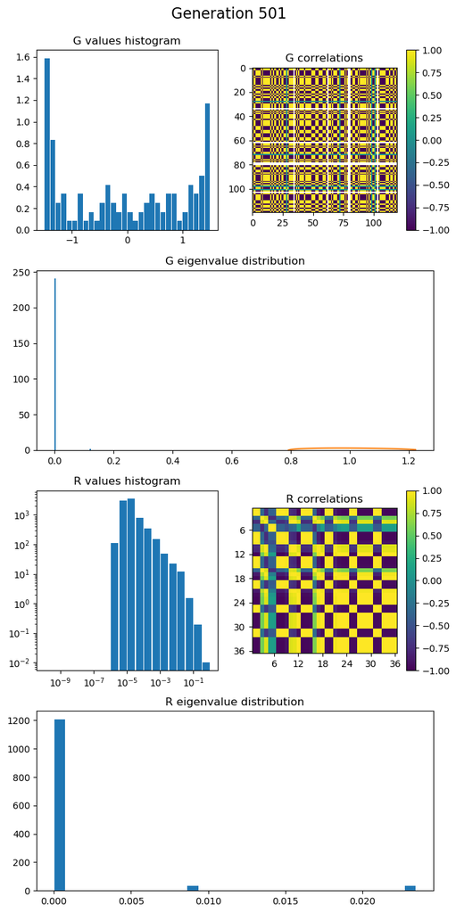

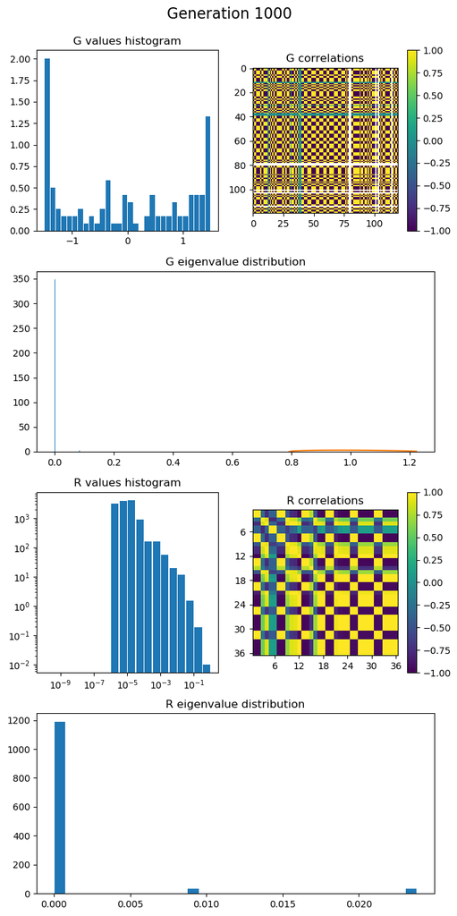

```julia
Nbatch, iPop, iGty = length(aDisChnDataElite), 1, 1

r = aDisChnMetaGty[1].dG/NPOP

Gstat = tStat(aDisChnGtyElite[iPop])
Rstat = tStat(aDisChnMetaGty[1].L2)

λval = [ λ for λ in mUtils.MPpdf(0,r)[2]:0.01:mUtils.MPpdf(0,r)[3] ]
MPval = [ mUtils.MPpdf(λ,r)[1] for λ in mUtils.MPpdf(0,r)[2]:0.01:mUtils.MPpdf(0,r)[3] ];

for iBatch in eachindex(aDisChnDataElite), iPop in eachindex(aDisChnData[iBatch].aEvoPop)
    gen = aDisChnDataElite[iBatch].aGen[iPop] + ( iBatch > 1 ? sum([ aDisChnData[jBatch].Ngen for jBatch in 1:iBatch-1]) : 0 )
    mEvoFunc.getGStat!(aDisChnDataElite[iBatch].aEvoPop[iPop], Gstat)
    aResp = mEvoFunc.getRStat!(aDisChnDataElite[iBatch].aEvoPop[iPop], Rstat)

    evGCor = eigvals( Symmetric(Gstat.cov) )
    evRCor = eigvals( Symmetric(Rstat.cov) )

    subplots(4,2,figsize=(7,14))
    subplot(421); title("G values histogram");  hist(vcat( [aDisChnDataElite[iBatch].aEvoPop[iPop].aGty[i].G for i in 1:aDisChnData[iBatch].aEvoPop[iPop].pN[2]]... ), collect(aDisChnData[iBatch].aEvoPop[iPop].aGty[1].gbounds[1]:.1:aDisChnData[iBatch].aEvoPop[iPop].aGty[1].gbounds[2]), density=true,rwidth=.9);
    subplot(422); title("G correlations"); imshow(Gstat.cor,cmap="viridis",vmin=-1,vmax=1); colorbar();
    subplot(412); title("G eigenvalue distribution"); hist(evGCor,30,density=true,log=false,rwidth=.9); plot(λval,MPval)

    subplot(425); title("R values histogram"); hist( reshape(aResp,:,1), [10^i for i in -10:.5:0], log=true, density=true, rwidth=.9); xscale("log");
    subplot(426); title("R correlations"); imshow(Rstat.cor,cmap="viridis",vmin=-1,vmax=1); colorbar(); xticks(disChnPopElite.aMetaGty[1].L-1:disChnPop.aMetaGty[1].L:disChnPop.aMetaGty[1].L2,disChnPop.aMetaGty[1].L:disChnPop.aMetaGty[1].L:disChnPop.aMetaGty[1].L2); yticks(disChnPop.aMetaGty[1].L-1:disChnPop.aMetaGty[1].L:disChnPop.aMetaGty[1].L2,disChnPop.aMetaGty[1].L:disChnPop.aMetaGty[1].L:disChnPop.aMetaGty[1].L2);
    subplot(414); title("R eigenvalue distribution"); hist(evRCor,30,density=true,log=false,rwidth=.9);

    suptitle("Generation $gen", fontsize=16)
    tight_layout(); subplots_adjust(top=0.9333);
end

gen = sum([aDisChnDataElite[jBatch].Ngen for jBatch in 1:Nbatch])
mEvoFunc.getGStat!(disChnPopElite, Gstat)
aResp = mEvoFunc.getRStat!(disChnPopElite, Rstat)

evGCor = eigvals( Symmetric(Gstat.cov) )
evRCor = eigvals( Symmetric(Rstat.cov) )

subplots(4,2,figsize=(7,14))
subplot(421); title("G values histogram");  hist(vcat( [disChnPopElite.aGty[i].G for i in 1:disChnPop.pN[2]]... ), collect(disChnPop.aGty[1].gbounds[1]:.1:disChnPop.aGty[1].gbounds[2]), density=true,rwidth=.9);
subplot(422); title("G correlations"); imshow(Gstat.cor,cmap="viridis",vmin=-1,vmax=1); colorbar();
subplot(412); title("G eigenvalue distribution"); hist(evGCor,30,density=true,log=false,rwidth=.9); plot(λval,MPval)

subplot(425); title("R values histogram"); hist( reshape(aResp,:,1), [10^i for i in -10:.5:0], log=true, density=true, rwidth=.9); xscale("log");
subplot(426); title("R correlations"); imshow(Rstat.cor,cmap="viridis",vmin=-1,vmax=1); colorbar();
xticks(disChnPopElite.aMetaGty[1].L-1:disChnPop.aMetaGty[1].L:disChnPop.aMetaGty[1].L2,disChnPop.aMetaGty[1].L:disChnPop.aMetaGty[1].L:disChnPop.aMetaGty[1].L2);
yticks(disChnPopElite.aMetaGty[1].L-1:disChnPop.aMetaGty[1].L:disChnPop.aMetaGty[1].L2,disChnPop.aMetaGty[1].L:disChnPop.aMetaGty[1].L:disChnPop.aMetaGty[1].L2);
subplot(414); title("R eigenvalue distribution"); hist(evRCor,30,density=true,log=false,rwidth=.9);

suptitle("Generation $gen", fontsize=16)
tight_layout(); subplots_adjust(top=0.9333);
```

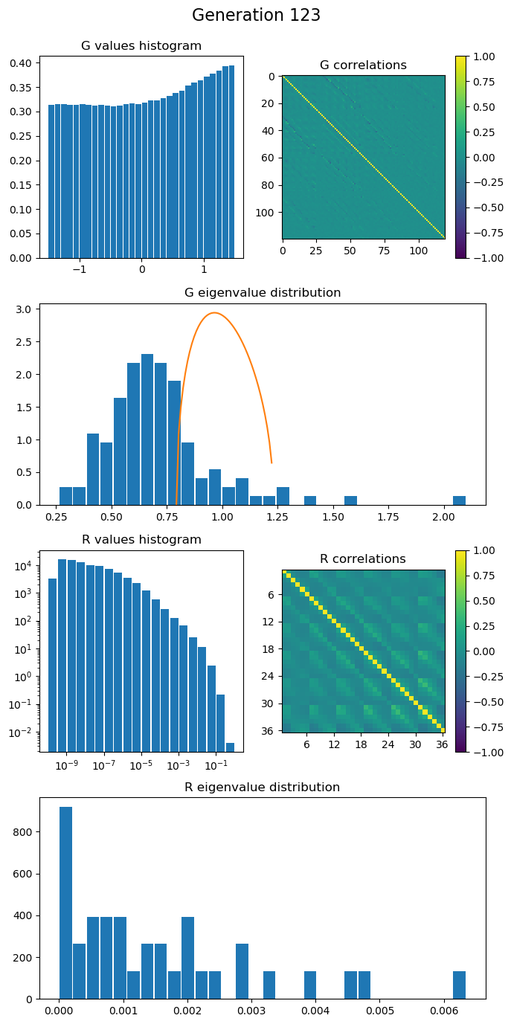

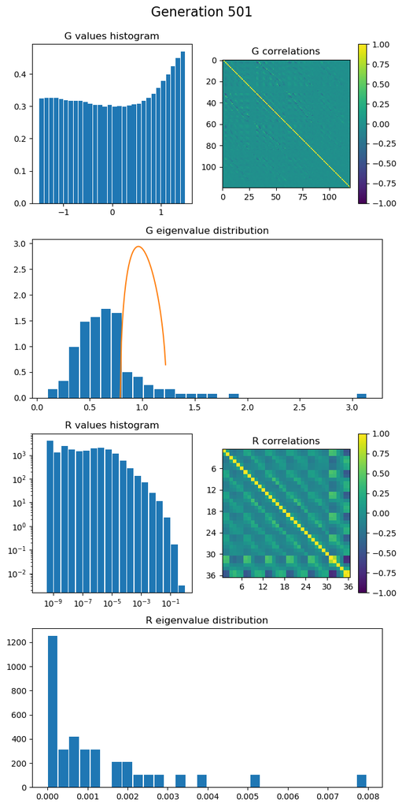

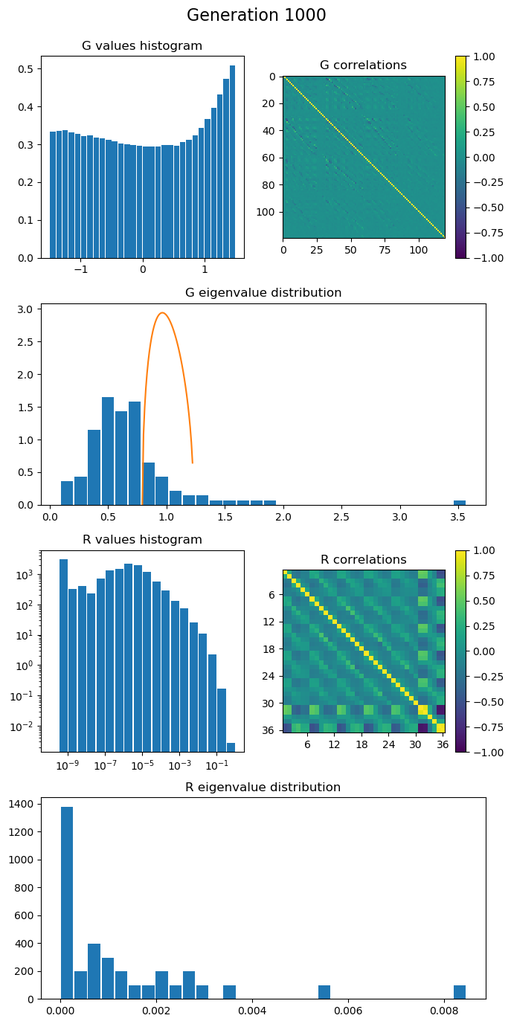

```julia
Nbatch, iPop, iGty = length(aDisChnDataNiche), 1, 1

r = aDisChnMetaGty[1].dG/NPOP

Gstat = tStat(aDisChnGtyNiche[iPop])
Rstat = tStat(aDisChnMetaGty[1].L2)

λval = [ λ for λ in mUtils.MPpdf(0,r)[2]:0.01:mUtils.MPpdf(0,r)[3] ]
MPval = [ mUtils.MPpdf(λ,r)[1] for λ in mUtils.MPpdf(0,r)[2]:0.01:mUtils.MPpdf(0,r)[3] ];

for iBatch in eachindex(aDisChnDataNiche), iPop in eachindex(aDisChnData[iBatch].aEvoPop)
    gen = aDisChnDataNiche[iBatch].aGen[iPop] + ( iBatch > 1 ? sum([ aDisChnData[jBatch].Ngen for jBatch in 1:iBatch-1]) : 0 )
    mEvoFunc.getGStat!(aDisChnDataNiche[iBatch].aEvoPop[iPop], Gstat)
    aResp = mEvoFunc.getRStat!(aDisChnDataNiche[iBatch].aEvoPop[iPop], Rstat)

    evGCor = eigvals( Symmetric(Gstat.cov) )
    evRCor = eigvals( Symmetric(Rstat.cov) )

    subplots(4,2,figsize=(7,14))
    subplot(421); title("G values histogram");  hist(vcat( [aDisChnDataNiche[iBatch].aEvoPop[iPop].aGty[i].G for i in 1:aDisChnData[iBatch].aEvoPop[iPop].pN[2]]... ), collect(aDisChnData[iBatch].aEvoPop[iPop].aGty[1].gbounds[1]:.1:aDisChnData[iBatch].aEvoPop[iPop].aGty[1].gbounds[2]), density=true,rwidth=.9);
    subplot(422); title("G correlations"); imshow(Gstat.cor,cmap="viridis",vmin=-1,vmax=1); colorbar();
    subplot(412); title("G eigenvalue distribution"); hist(evGCor,30,density=true,log=false,rwidth=.9); plot(λval,MPval)

    subplot(425); title("R values histogram"); hist( reshape(aResp,:,1), [10^i for i in -10:.5:0], log=true, density=true, rwidth=.9); xscale("log");
    subplot(426); title("R correlations"); imshow(Rstat.cor,cmap="viridis",vmin=-1,vmax=1); colorbar(); xticks(disChnPopNiche.aMetaGty[1].L-1:disChnPop.aMetaGty[1].L:disChnPop.aMetaGty[1].L2,disChnPop.aMetaGty[1].L:disChnPop.aMetaGty[1].L:disChnPop.aMetaGty[1].L2); yticks(disChnPop.aMetaGty[1].L-1:disChnPop.aMetaGty[1].L:disChnPop.aMetaGty[1].L2,disChnPop.aMetaGty[1].L:disChnPop.aMetaGty[1].L:disChnPop.aMetaGty[1].L2);
    subplot(414); title("R eigenvalue distribution"); hist(evRCor,30,density=true,log=false,rwidth=.9);

    suptitle("Generation $gen", fontsize=16)
    tight_layout(); subplots_adjust(top=0.9333);
end

gen = sum([aDisChnDataNiche[jBatch].Ngen for jBatch in 1:Nbatch])
mEvoFunc.getGStat!(disChnPopNiche, Gstat)
aResp = mEvoFunc.getRStat!(disChnPopNiche, Rstat)

evGCor = eigvals( Symmetric(Gstat.cov) )
evRCor = eigvals( Symmetric(Rstat.cov) )

subplots(4,2,figsize=(7,14))
subplot(421); title("G values histogram");  hist(vcat( [disChnPopNiche.aGty[i].G for i in 1:disChnPop.pN[2]]... ), collect(disChnPop.aGty[1].gbounds[1]:.1:disChnPop.aGty[1].gbounds[2]), density=true,rwidth=.9);
subplot(422); title("G correlations"); imshow(Gstat.cor,cmap="viridis",vmin=-1,vmax=1); colorbar();
subplot(412); title("G eigenvalue distribution"); hist(evGCor,30,density=true,log=false,rwidth=.9); plot(λval,MPval)

subplot(425); title("R values histogram"); hist( reshape(aResp,:,1), [10^i for i in -10:.5:0], log=true, density=true, rwidth=.9); xscale("log");
subplot(426); title("R correlations"); imshow(Rstat.cor,cmap="viridis",vmin=-1,vmax=1); colorbar();
xticks(disChnPopNiche.aMetaGty[1].L-1:disChnPop.aMetaGty[1].L:disChnPop.aMetaGty[1].L2,disChnPop.aMetaGty[1].L:disChnPop.aMetaGty[1].L:disChnPop.aMetaGty[1].L2);
yticks(disChnPopNiche.aMetaGty[1].L-1:disChnPop.aMetaGty[1].L:disChnPop.aMetaGty[1].L2,disChnPop.aMetaGty[1].L:disChnPop.aMetaGty[1].L:disChnPop.aMetaGty[1].L2);
subplot(414); title("R eigenvalue distribution"); hist(evRCor,30,density=true,log=false,rwidth=.9);

suptitle("Generation $gen", fontsize=16)
tight_layout(); subplots_adjust(top=0.9333);
```

## Response Analysis

```julia
Nbatch, iPop, Nio = length(aDisChnData), 1, length(disChnEnv.IOidl)

fmax = maximum([ gty.pF[1] for gty in disChnPop.aGty[1:disChnPop.pN[2]] ])
iGty = findall( f -> f == fmax, [ gty.pF[1] for gty in disChnPop.aGty[1:disChnPop.pN[2]] ])[1]

fmin = minimum([ gty.pF[1] for gty in disChnPop.aGty[1:disChnPop.pN[2]] ])
iGtyLow = findall( f -> f == fmin, [ gty.pF[1] for gty in disChnPop.aGty[1:disChnPop.pN[2]] ])[1]

# within batch
# fittestFluxPattern = tFluxPattern(disChnEnv,aDisChnData[Nbatch].aEvoPop[iPop].aGty[iGty])
# fittestCrntPtrn = tCrntPattern(disChnEnv,aDisChnData[Nbatch].aEvoPop[iPop].aGty[iGty])

# @time mEvoFunc.getFluxStat!(disChnEnv,aDisChnData[Nbatch].aEvoPop[iPop].aGty[1],fittestFluxPattern);
# @time mEvoFunc.getCrntPtrn!(aDisChnData[Nbatch].aEvoPop[iPop].aGty[1],fittestFluxPattern,fittestCrntPtrn);

# inputNodes = findall(x -> x == 1.0, disChnEnv.IOidl[io][1])
# outputNodes = aDisChnMetaGty[1].L2mL .+ findall(x -> x >= 1/SYSTEMSIZE, disChnEnv.IOidl[io][2]);

# last evolution step
fittestFluxPattern = tFluxPattern(disChnEnv,disChnPop.aGty[iGty])
fittestCrntPtrn = tCrntPattern(disChnEnv,disChnPop.aGty[iGty])

@time mEvoFunc.getFluxStat!(disChnEnv,disChnPop.aGty[iGty],fittestFluxPattern);
@time mEvoFunc.getCrntPtrn!(disChnPop.aGty[iGty],fittestFluxPattern,fittestCrntPtrn);

aInputNodes = [ findall(x -> x == 1.0, disChnEnv.IOidl[i][1]) for i in eachindex(disChnEnv.IOidl) ]
aOutputNodes = [ aDisChnMetaGty[1].L2mL .+ findall(x -> x >= 1/SYSTEMSIZE, disChnEnv.IOidl[i][2]) for i in eachindex(disChnEnv.IOidl) ];;
```

```
 15.526615 seconds (25.37 M allocations: 8.418 GiB, 8.39% gc time)
  0.209964 seconds (507.91 k allocations: 24.810 MiB)
```

```julia
for io in 1:Nio
    mat"""
        G = digraph($(fittestCrntPtrn.aV[io][2]), $(fittestCrntPtrn.aV[io][1]), $(fittestCrntPtrn.Jave[io]));
        LWidths = ( 10*G.Edges.Weight/max(G.Edges.Weight) );

        ioInside = double($io);

        subplot(2,2,ioInside)
        pl = plot(G,'Layout','force','LineWidth',LWidths,'NodeLabel',{});

        highlight(pl,$(aInputNodes[io]),'NodeColor','g');
        highlight(pl,$(aOutputNodes[io]),'NodeColor','r');
    """
end
#plot(G,'Layout','force','EdgeLabel',G.Edges.Weight,'LineWidth',$(LWidths))
```

[output not shown]